# Systems biological analysis of immunity to dengue - Kwissa et al.

Philippe Boileau

15/10/2019

# Prepare the Data

The microarray data is fetched from the GEO (accession number GSE51808). The data consists of the transcriptome of blood samples from 56 Thai males, 28 of which were hospitalized with severe dengue, 19 patients which were convalescent 4 weeks after contracting dengue and 9 healthy controls. Among the patients with dengue, 18 had a fever and 10 had a hemorrhagic fever.

The data was filtered; only the 500 most variable genes were retained. The transcriptome data of the 9 healthy controls were removed and used as a background dataset for cPCA and scPCA. The remaining samples consist of the target data.

# Dimension Reduction Methods

The target (and where appropriate the background) were subjected to various dimension reduction methods. Ideally, three clusters should be found in the target dataset: patients with dengue fever, with dengue hemorrhagic fever, and patients convalescent after 4 weeks.

## PCA

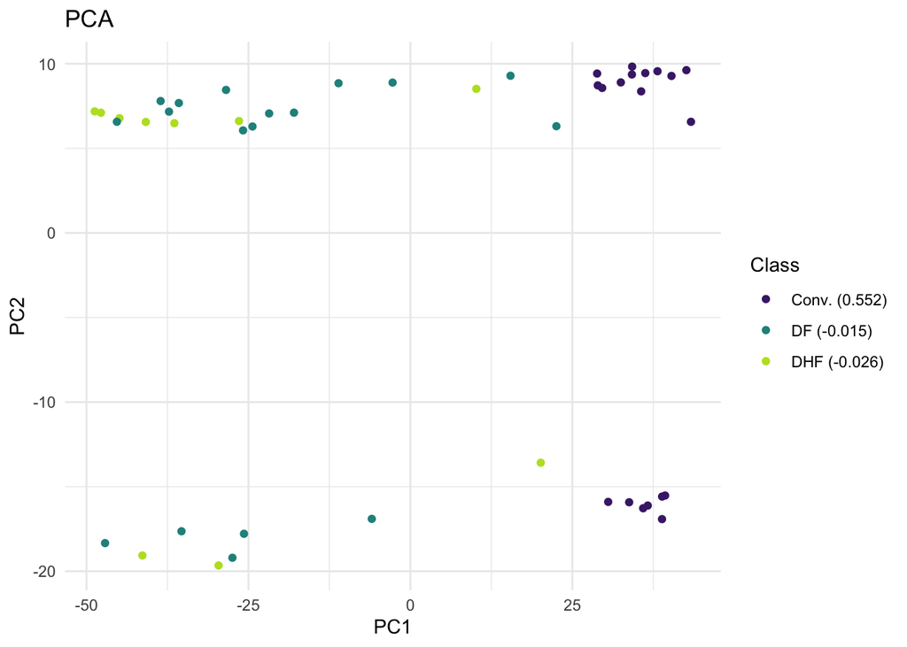

## cPCA

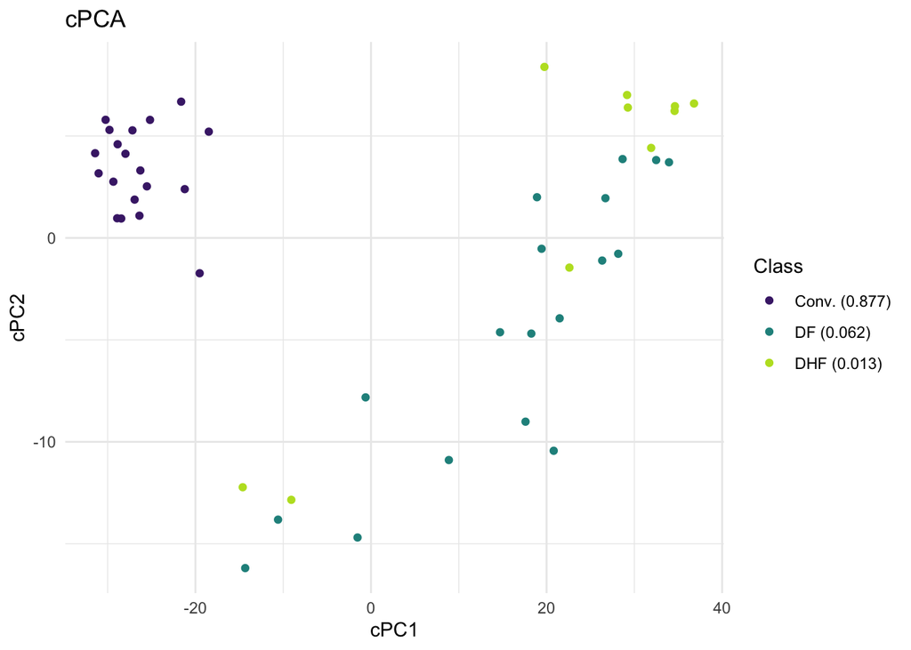

### cPCA Number of Centers

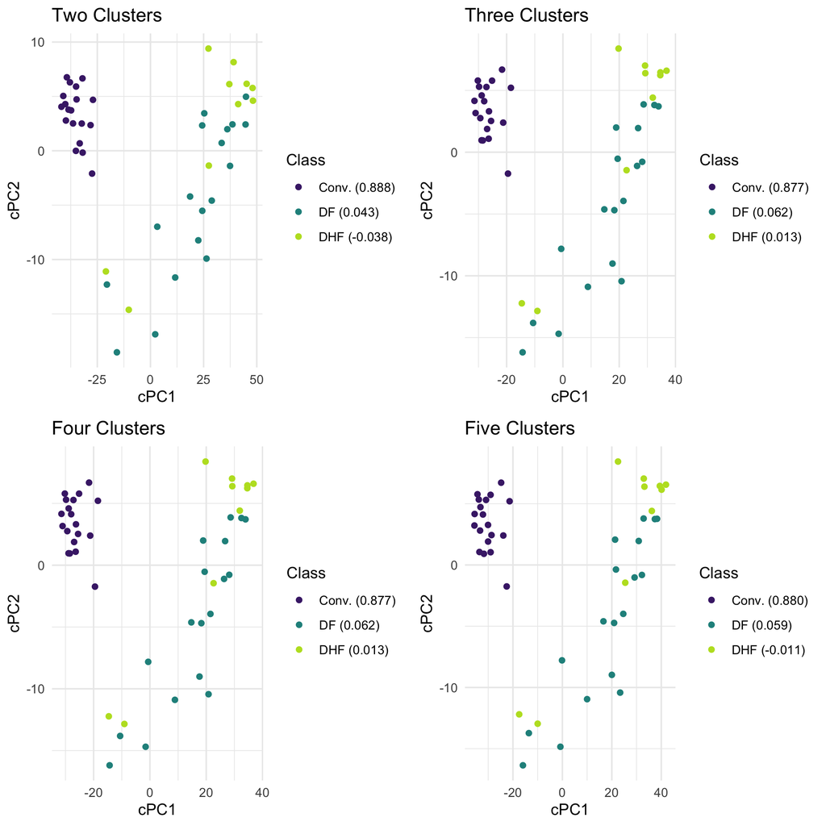

## scPCA

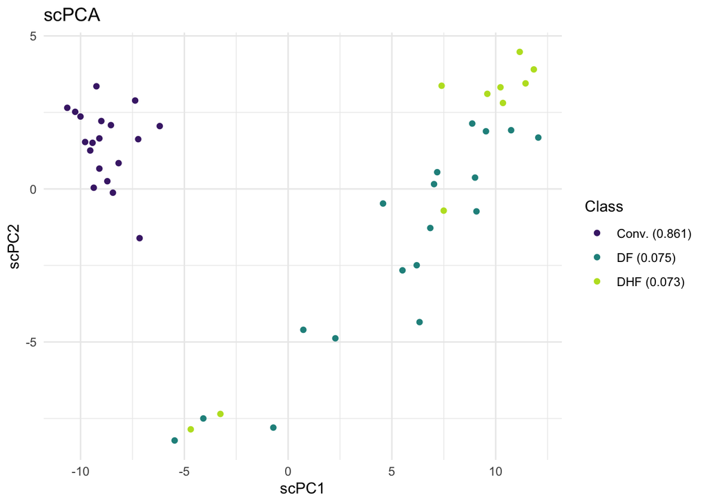

### scPCA Number of Centers

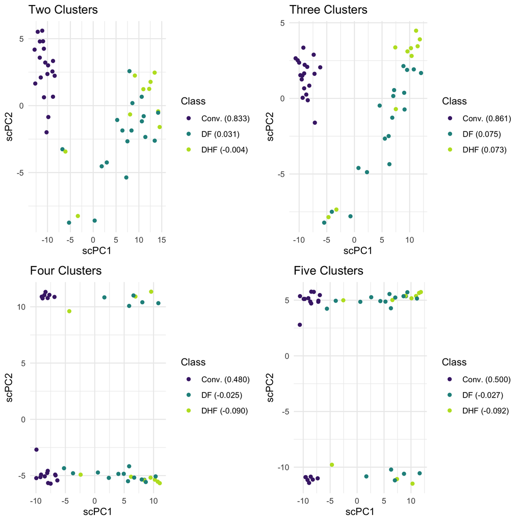

### Genes With Non-Zero Loadings

Tables included in the appendix of the manuscript.

### Comparison of cPCA and scPCA Loadings

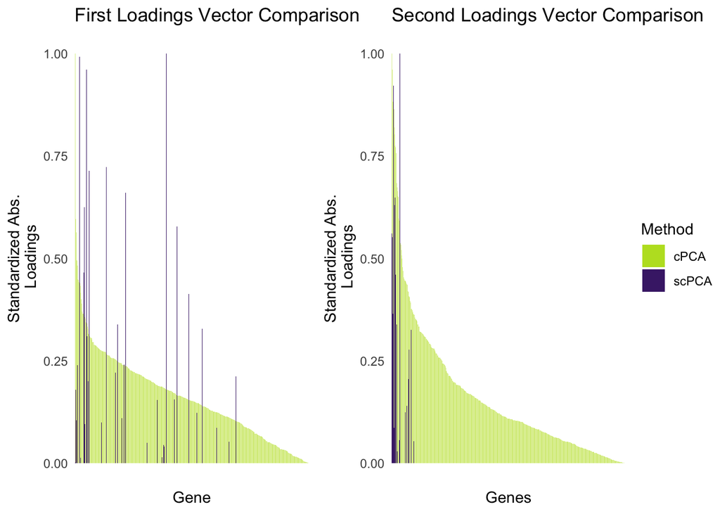

## cPCA (Tuned with Cross-Validation)

3-fold cross-validation was used to tune the contrastive parameter.

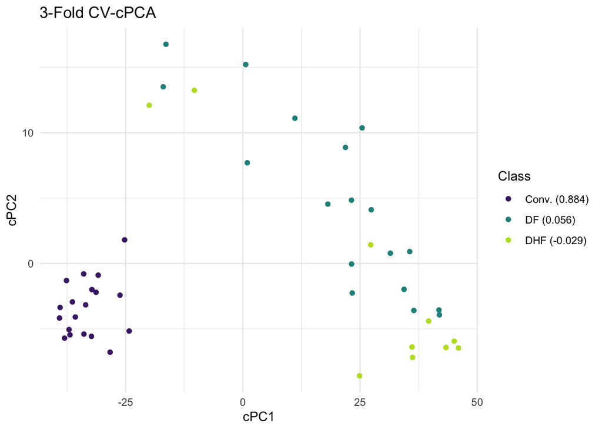

## scPCA (Tuned with Cross-Validation)

3-fold cross-validation was used to tune the hyperparameters.

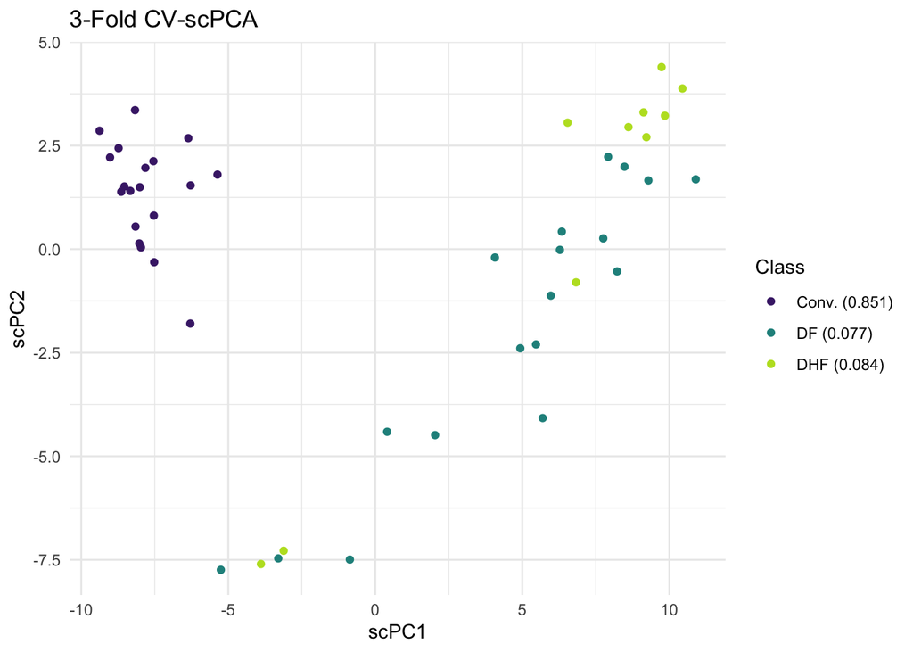

## t-SNE

### With Initial PCA Step

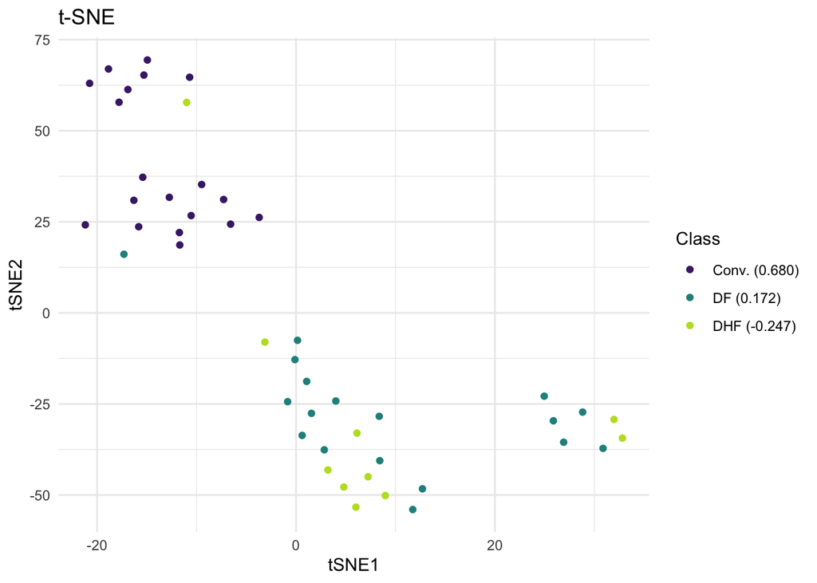

### Without Initial PCA Step

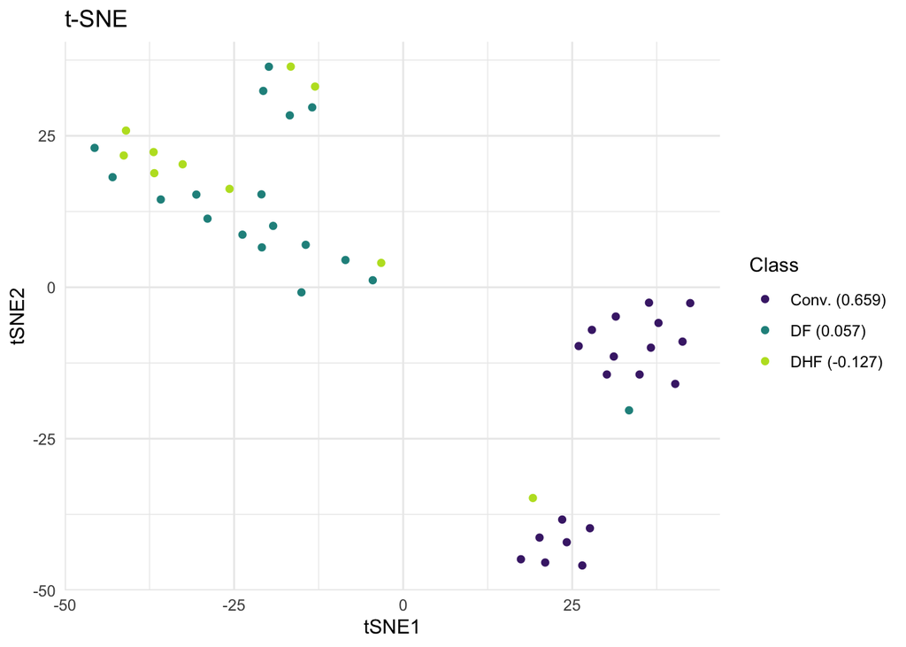

## UMAP

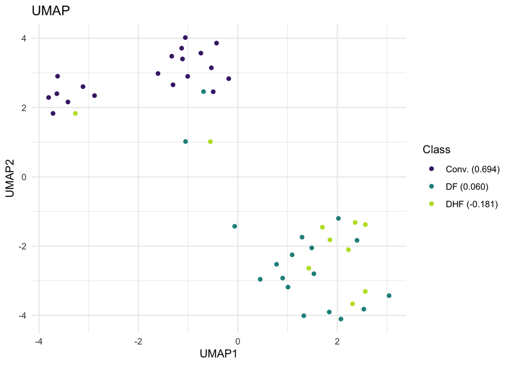

# Combined Plots

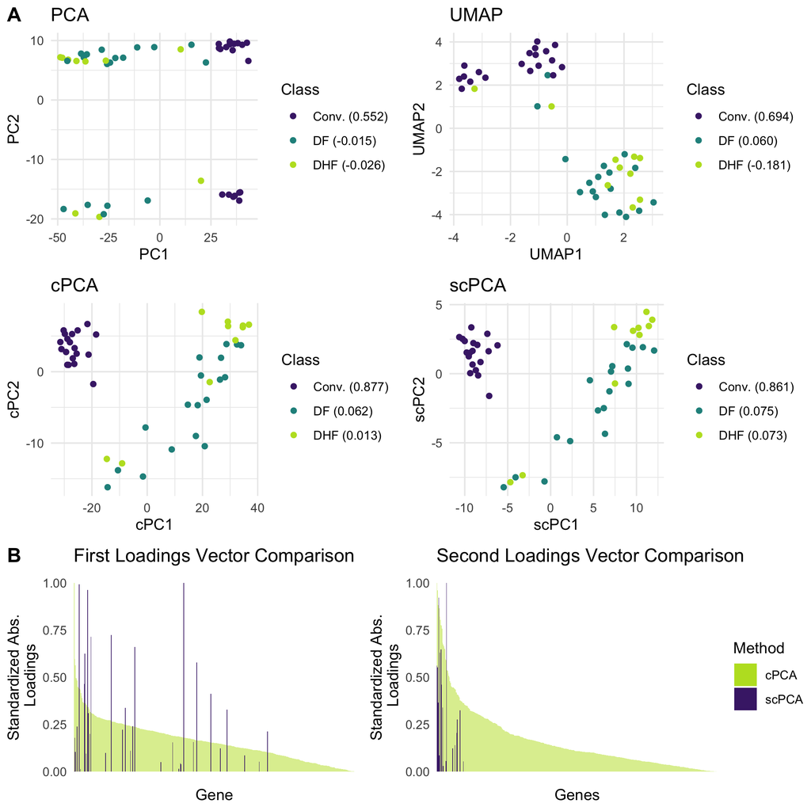